# Models & Tools

## 1. Introduction

In this section we present how models and tools aimed to measure, monitor and/or assess multiple facets of biodiversity and ecosystems services.

**Models**

“Models” are qualitative or quantitative descriptions of key components of a system and of relationships between those components ([IPBES 2016](https://www.ipbes.net/document-library-catalogue/methodological-assessment-report-scenarios-and-models-biodiversity-and)).

Models, approaches and tools have been designed to operate within one or multiple socio-economic and/or biophysical components and to provide information for spatial planning and/or to be used as an input for further analysis (e.g., scenario assessments).

In this section we present how models were designed to operate and integrate multiple components of socioeconomic and biophysical systems (**Figure below**). For instance, some models have a very narrow scope of application such as PROMETHEUS for fires; others tend to integrate more components such as Earth System Models (ESMs) or Integrated Assessment Models (IAMs). Panel (b) in Figure below shows a detailed description of models for biodiversity and physical features.

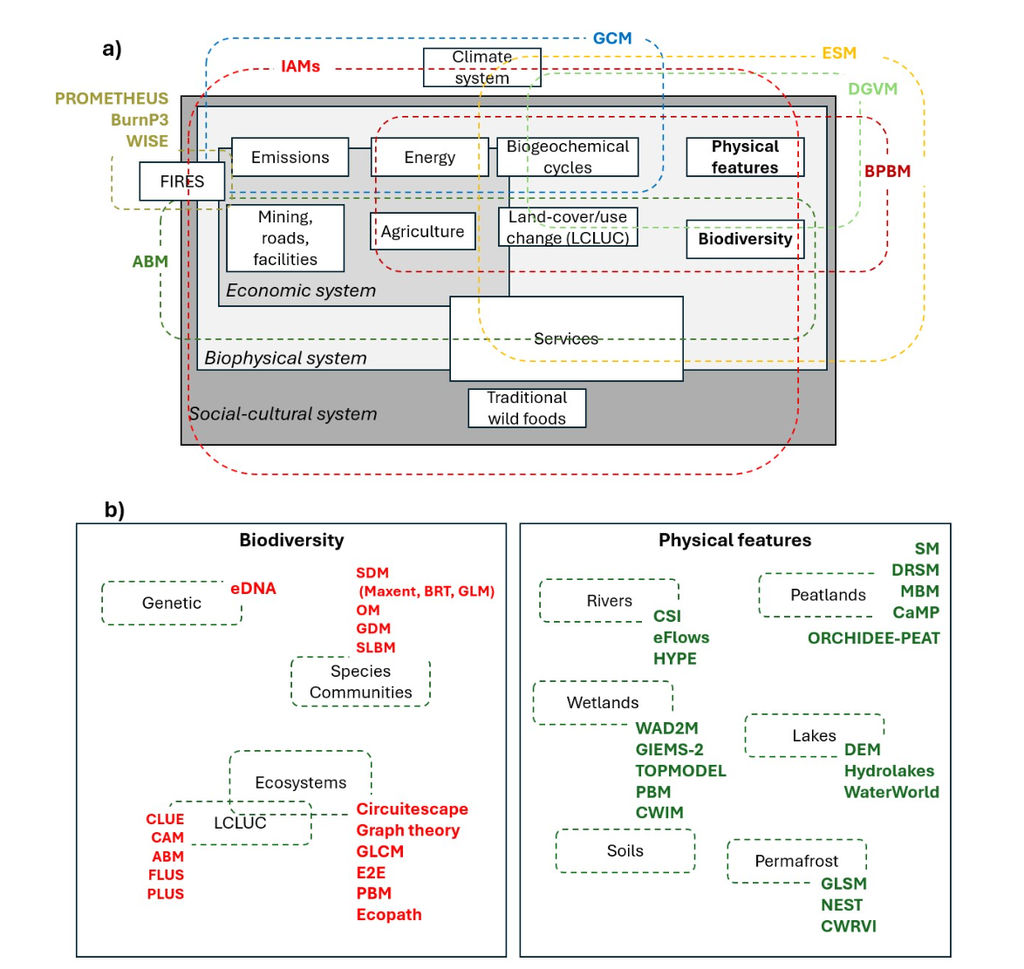

Models and approaches to measure, assess and monitor multiple aspects of a) biophysical, economic and socio-cultural systems (adapted from Giupponi et al. 2022), and b) detail of models models for biodiversity and physical features. ABM (Agent-Based Model), BPBM (Biophysical Process-Based Model), BRT (Boosted Regression Trees), BurnP3 (spatial fire simulation model), CAM (Cellular Automata Model), CaMP (Canadian Model for Peatlands), CLUE (Conversion of Land Use and its Effects), Circuitscape (connectivity), CSI (Connectivity Status Index-Rivers), CWIM (Canadian Wetland Inventory Map), DGVM (Dynamic Global Vegetation Model), DRSM (Direct Remote Sensing), E2E (End to End Model), Ecopath (aquatic webs), eDNA (Environmental DNA), eFlows (Environmental flows), ESM (Earth System Model), GCM (General Circulation Model), FLUS (Future Land Use Simulation model), GDM (Generalized Dissimilarity Model), GLCM (General Landscape Connectivity Model), Graph theory (connectivity), HYPE (HYdrological Predictions for the Environment), IAMs (Integrated Assessment Models), MBM (Mass Balance Models), Maxent (Maximum Entropy), OM (Occupancy Model), ORCHIDEE-PEAT (Organising Carbon and Hydrology In Dynamic Ecosystems-Peatlands), PBM (Process-Based Model), PLUS (Patch-generating Land Use Simulation), PROMETHEUS (deterministic wildland fire growth simulation model), SDM (Species Distribution Model), SLBM (Site Level Biodiversity metrics), SM (Stratify and Multiply), TOPMODEL (TOPography-based hydrological model), WISE (Wildfire Simulation Engine).

**Tools**

Multiple institutions and initiatives have developed and maintained tools that house models described above. For instance, [Bon in A Box](https://boninabox.geobon.org/) a [GEO BON](https://geobon.org/) global initiative, is in the process of developing multiple data-to-indicator pipelines to help biodiversity and ecosystem services assessment and monitoring. InVEST, ARIES and Co$tingNature are tools for ecosystem services assessment. Marxan, Zonation, and CAPTAIN are tools for spatial prioritization. The **Figure below** shows in detail those tools for biodiversity and physical features that can support assessment and inform multiple partners in the HJBL in the decision-making process.

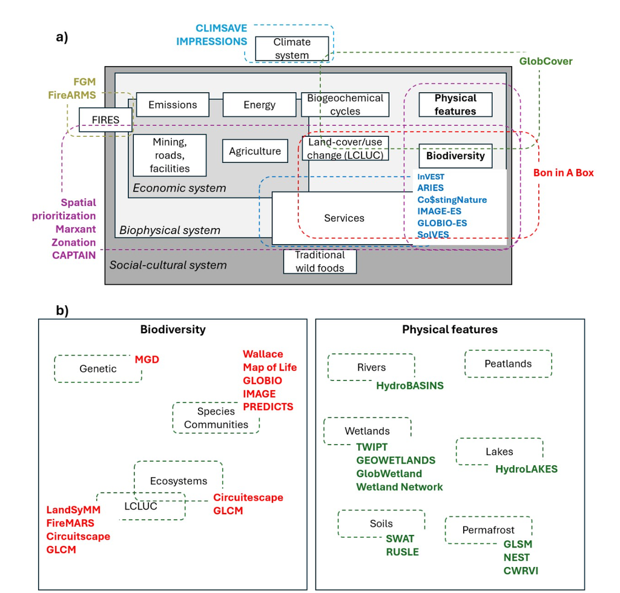

**Tools to measure, assess and monitor multiple aspects of a) biophysical, economic and socio-cultural systems** (adapted from [Giupponi et al. 2022](https://iris.unive.it/bitstream/10278/3751142/1/Giupponi%20et%20al%202022%20SESMO.pdf)), and b) detail of tools for biodiversity and physical features. ARIES (ecosystem services accounts), Bon in a Box (GEO BON tools), CAPTAIN (Conservation area prioritization through artificial intelligence), CLIMSAVE (assess climate change impacts and vulnerabilities for a range of sectors), Co$tingNature (mapping supply and demand of ecosystem services), CWRVI (Canadian Water Resources Vulnerability Index to Permafrost Thaw), FGM (Projects related to Canadian fires), FireMARS (Fire monitoring and reporting tool), Geo Wetlands (Earth Observation (EO) based mapping, monitoring, inventory and assessment of wetlands), GLCM (General Landscape Connectivity Model), GlobCover (global composites and land cover maps), GLOBIO-ES (calculates the current state, trends and possible future scenarios of ecosystem services globally), GlobWetlands Africa (Toolbox for analysis and processing satellite imagery and for building models, maps and applications), GLSM (Global Land Surface Model), HydroBASINS (sub-basin boundaries at a global scale), HydroLAKES (shoreline polygons of all global lakes), IMAGE-ES (Integrated Model to Assess the Global Environment), IMPRESSIONS (extension of CLIMSAVE), InVEST (map and value the goods and services from nature), LandSyMM (Land system changes across scales), Marxant (solutions to conservation planning problems), NEST (The Northern Ecosystems Soil Temperature model), RUSLE (Revised Universal Soil Loss Equation), SolVES (Social Values for Ecosystem Services ), SWAT (Soil & Water Assessment Tool), TWIPT (The Wetland Intrinsic Potential tool), Wetland Network (Practical tools and resources to better understand and conserve wetlands, Canada), Zonation (spatial priority ranking software).

## **2. Biophysical features (BFs)**

We have included not only models to measure or assess some facet of biodiversity but physical models that can be important to indirectly monitor biodiversity and ecosystem services, in particular those that use remote sensing as source of data.

- BF-1: Biodiversity.
- BF-2: Quantifying carbon storage.
- BF-3: Permafrost.
- BF-4: Rivers & Basins.
- BF-5: Wetlands.
- BF-6: Lakes.
- BF-7: Water.

## 3. Ecosystem services (ESs)

We focused our review on some ecosystem services in the region (carbon storage-climate stability and traditional use of biota-food security).

- ES-1: Ecosystem services.

## 4. Spatial Prioritization

- SP: Spatial Prioritization.

## 5. Topics to consider when applying models

**4.1 Multiscale analysis**

**What is it?**

Processes and patterns of ecological systems operate and vary as a function of spatial (extent and resolution) and temporal scale (e.g.,[Hewitt et al 2017](https://onlinelibrary.wiley.com/doi/abs/10.1002/9780470015902.a0021903.pub2)) and it is expected that the response to multiple anthropogenic drivers also vary in space and time (Bastazini et al. 2021.

New sources of data sets, vast amount of data (e.g., remote sensing and citizen science) and the need to evaluate and respond to local and regional realities have accelerated the development of these multiscale spatio-temporal analyses.

**Some evidence**

Multiscale dependance has been documented widely:

- Biophysical processes, identify patterns in nature (e.g., [Brian & Catford 2023](https://www.taylorfrancis.com/chapters/edit/10.1201/9781003314332-5/ecological-scale-context-dependence-joshua-brian-jane-catford), [Mod et al. 2020](https://besjournals.onlinelibrary.wiley.com/doi/full/10.1111/1365-2745.13434), [Meng et al. 2023](https://www.science.org/doi/10.1126/sciadv.adi1279), [Wand & Loreau 2014](https://onlinelibrary.wiley.com/doi/abs/10.1111/ele.12292?casa_token=5eoyeg-MBcsAAAAA%3ADKLodzekMQWDHTXProtvWddQ2Z_Jgf4GNjsPj-r2MytJW-TE2fXghnuACRSYxEX2euI_OX_Ndpavmbfb), [Spake et al. 2020](https://onlinelibrary.wiley.com/doi/10.1111/ele.13641), [Leroy et al. 2023](https://www.sciencedirect.com/science/article/pii/S1439179123000117)).
- Biodiversity patterns ([Hulbert & Jetz 2007](https://www.pnas.org/doi/full/10.1073/pnas.0704469104?doi=10.1073/pnas.0704469104), [Chase et al. 2018](https://pubmed.ncbi.nlm.nih.gov/30182500/), [Jarzyna & Jetz 2018](https://www.nature.com/articles/s41467-018-04889-z)).
- Inform decision making to secure the provision of ecosystem services ([Andersonn et al. 2015](https://www.sciencedirect.com/science/article/abs/pii/S2212041614000850), [Lindborg et al. 2017](https://esajournals.onlinelibrary.wiley.com/doi/10.1002/ecs2.1741), [Liu et al. 2017](https://www.nature.com/articles/s41598-017-09863-1), [Raudsepp-Hearne & Peterson 2016](https://www.jstor.org/stable/26269960), [Le Provost et al. 2023](https://www.nature.com/articles/s41559-022-01918-5)).
- Protection of biodiversity ([Ekroos et al 2016](https://www.frontiersin.org/articles/10.3389/fevo.2015.00145/full), [Hurlbert & Jetz 2007](https://www.pnas.org/doi/10.1073/pnas.0704469104), [Slabbert et al. 2020](https://www.ncbi.nlm.nih.gov/pmc/articles/PMC7520218/), [Mayor et al. 2015](https://journals.plos.org/plosone/article?id=10.1371/journal.pone.0125579)).
- Management ([Ladouceur et al. 2023](https://besjournals.onlinelibrary.wiley.com/doi/full/10.1111/1365-2745.14063)).
- Invasive alien species ([Kotowska et al. 2022](https://besjournals.onlinelibrary.wiley.com/doi/full/10.1111/1365-2664.14143)).
- Ecosystem services ([Qin et al. 2023](https://pubmed.ncbi.nlm.nih.gov/37943440/), [Liu et al. 2017](https://www.nature.com/articles/s41598-017-09863-1), [Hein et al. 2005](https://www.sciencedirect.com/science/article/pii/S0921800905002028?casa_token=p_zIzbIOs9oAAAAA:1Xl1beJETr7wwfhauoNbUWfyfU83LdkMkN6aUzTplOz5oesz-KbMzZ2rC_QWcYQGfySsnyp8Otc),

**How has it been addressed?**

*Using local datasets*

For instance, [Dinerstein et al. (2020)](https://www.science.org/doi/10.1126/sciadv.abb2824), identified global areas providing co-benefits by protecting biodiversity and carbon stocks aimed to secure global climate stability (Global Safety Net, GSN). However, [Finkelstein et al. (2023)](https://www.facetsjournal.com/doi/10.1139/facets-2022-0126) applied the same approach in Ontario (Canada), using local data sets, and found that “when region-specific data are incorporated, Ontario is even more significant than what is shown in the GSN, especially in terms of carbon stocks in forested and open peatlands.” [Zhu et al. (2021)](https://www.science.org/doi/10.1126/sciadv.abe4261) went further and addressed the issue of spatial scales in Asia, arguing that a “framework should be capable of identifying priorities at each scale (regional, biome, and national)”. They proposed “a stepwise approach based on scalable priorities at regional, biome, and national levels that can complement potential Convention on Biological Diversity targets of protecting 30% land in the post-2020 global biodiversity framework.”

*Integrating multiple knowledge systems*  
Fire regimes characterization using remote sensing ([Hanes et al. 2018](https://cdnsciencepub.com/doi/full/10.1139/cjfr-2018-0293), [Coops et al. 2018](https://journals.plos.org/plosone/article?id=10.1371/journal.pone.0197218)) have been used to inform management activities for government agencies ([Erni et al. 2019](https://cdnsciencepub.com/doi/10.1139/cjfr-2019-0191)) and along with Indigenous land stewardship have provided tools to advance proactive fire mitigation ([Copes et al. 2022](https://esajournals.onlinelibrary.wiley.com/doi/10.1002/eap.2736)).

**4.2 Integrating top-down and bottom-up approaches**

Top-down approaches are driven by policy mandates and/or directives, requiring changes in socioeconomic systems (e.g., SDGs and CBDs goals and targets) and designed to force behavioral change through policy. Top-down approaches are usually the first approximation in model implementation, scenario assessment (e.g., [Moss et al. 2010](https://www.nature.com/articles/nature08823), [Meinshause et al. 2020](https://gmd.copernicus.org/articles/13/3571/2020/), and [Popp et al. 2017](https://www.sciencedirect.com/science/article/pii/S0959378016303399)), and tools’ development (e.g., [Map of Life](https://mol.org/), [InVEST](https://naturalcapitalproject.stanford.edu/software/invest), [GLOBIO-ES](https://www.globio.info/what-is-globio)). However, there is also growing interest to develop and implement bottom-up approaches (e.g., [Wallner et al. 1996](https://journals.sagepub.com/doi/abs/10.1068/a281763?casa_token=4QOFTXw7L_IAAAAA:baFgJB6DlzomfX-FKKABC_6qcw016L5LEG67AP0M8gqTxOGSCrGbYAB5wXUsQBkYVeeTWuziHZzp)), that is those approaches that influence policy through collective behavior (individual actions that can propel massive impact when adopted by communities) and/or motivate research to answer questions at local scales. For instance, [GLOBIOM](https://iiasa.ac.at/models-tools-data/globiom) is “used to analyze the competition for land use between agriculture, forestry, and bioenergy, which are the main land-based production sectors. The model is built following a bottom-up setting based on detailed grid-cell information, providing the biophysical and technical cost information”.

There is also growing interest in evaluating top-down approaches with local and regional data sets ([Siabi et al. 2023](https://www.sciencedirect.com/science/article/pii/S2212095523000263)), economic sectors ([Calheiros et al. 2023](https://www.mdpi.com/2071-1050/16/4/1548)), and integrating top-down and bottom-up approaches ([Ding et al. 2022](https://www.sciencedirect.com/science/article/pii/S2095809922006403), [Eicken et al. 2021](https://academic.oup.com/bioscience/article/71/5/467/6238581)) .

**Model Integration**

Model integration seems to offer a pathway to understand complex systems and inform decision making. However, current models are global, make multiple assumptions and can generate high spatial and temporal uncertainty. Integrated Assessment Models (IAMs) have been developed to respond to this need of integration. Originally, IAMs were developed to evaluate multiple scenarios of climate change, mainly focused on economic sectors (e.g., energy) aimed to inform alternative policies in GHG emissions reduction. Recently, they have been extended to other sectors and customized to include land cover and land use change, some biodiversity facets and ecosystem services. However, their implementation is limited.

**Coupling models and tools**

Some analyses require coupling several models to accomplish their objectives. For instance,

- projecting land cover and land use change (LCLUC) to assess ecosystem services under multiple scenarios requires coupling Multi-Objective Programming (MOP) to optimized solutions for each land use type subject to a series of constraints specified by a given scenario and the Dynamic Conversion of Land Use and its Effects (Dyna-CLUE) to allocate the predicted land use changes to grid cells following a bottom-up process ([Wang et al. 2018](https://www.sciencedirect.com/science/article/abs/pii/S1470160X18304886)).
- [Li et al. (2023)](https://peerj.com/articles/15285/) have used the “Patch-generating Land Use Simulation (PLUS) to assess the features of land utilization conversion and forecasted land utilization under three development patterns in 2030” and then the “InVEST model to estimate changes in carbon storage trends under three development scenarios in 2000, 2010, 2020, and 2030 and the impact of socioeconomic and natural factors on carbon storage”.

There are also strategies to ensemble models to reduce uncertainty. For instance, [Hooftman et al. (2022)](https://www.sciencedirect.com/science/article/abs/pii/S221204162100156X) and [Willcock et al (2023)](https://www.science.org/doi/full/10.1126/sciadv.adf5492) evaluated the effect of ensemble models to reduce certainty gaps in spatially explicit ecosystem services. (e.g, using multiple ecosystem accounting platforms such as InVEST, ARIES, and Co$tingNature).

[Stralberg et al. (2015)](https://esajournals.onlinelibrary.wiley.com/doi/full/10.1890/13-2289.1#i1051-0761-25-1-52-Meehl1) used multiple GCMs projections and SDMs to evaluate signal vs. noise in the response of bird abundance to climate change. They found that for 58% of 80 boreal songbird species over the next 30 years—increasing to 88% of species by the end of the century—the climate change “signal” in projections of abundance was greater than the “noise” generated by uncertainty due to a combination of sampling error, variable selection, and choice of global climate model (GCM)” ([Stralberg et al. 2015](https://esajournals.onlinelibrary.wiley.com/doi/full/10.1890/13-2289.1#i1051-0761-25-1-52-Meehl1)).

**A non-exhaustive list of models & Tools!**

We acknowledge that there may be models, approaches and tools out there that escaped this review, while noting that there are some biophysical components and ecosystem services that were more explored and covered than others. So, **further efforts should focus on tackling these gaps and updating models when possible**.

**To do:**

- Review this for additional models: [EcoService Models Library (ESML)](https://esml.epa.gov/search/ems)